# Notebook

## Overall analysis plan - Re-run analysis with data cleaned by Dr Kawsara

### After Discussion

1. Use elbow method and 2 groups better chance for getting p values

completed

2. Use random forest or similar to predict the 2 groups

completed

3. Use shap scores to pick the variables to describe

completed

4. Use these variables to predict mortality (in hospital)

completed

### Data loading and processing

```python
import pandas as pd

# Define the file path
file_path = r'/mnt/c/Users/abbas/Downloads/Endocarditis - clean.xlsx'

# Define the sheet name
sheet_name = 'Endocarditis - clean - Transpos'

# Read the specific sheet from the Excel file
clean_df = pd.read_excel(file_path, sheet_name=sheet_name)

# Display the first few rows of the DataFrame
print(clean_df.head())
```

```
        MRN  age  sexMale1   Race    BMI  HTN  HLD  DM  CKD  HepatitisBorC  \
0  E2638587   33         0  White  21.30    0    0   0    0              0
1   E100904   72         1  White  32.08    1    1   1    0              0
2   E101903   30         1  White  21.30    0    0   0    0              0
3  E1062752   54         1  White  33.30    1    1   1    0              0
4   E106740   70         0  White  26.96    1    1   0    0              0

   ...  admissiondate  Strokedate          Surgerydate  \
0  ...     2021-03-14         NaN  2021-03-19 00:00:00
1  ...     2018-04-24         NaN  2018-05-04 00:00:00
2  ...     2017-10-23     43033.0  2017-10-27 00:00:00
3  ...     2016-04-14         NaN  2019-04-22 00:00:00
4  ...     2019-03-25     43549.0  2019-04-02 00:00:00

   DaysFromstroketosurgery  TotalLOS  Readmission    lastencounterdate  \
0                      NaN        52          0.0  2021-05-27 00:00:00
1                      NaN        24          1.0               #NULL!
2                      2.0        54          0.0  2019-12-02 00:00:00
3                      NaN        33          1.0  2019-08-16 00:00:00
4                      8.0        73          0.0  2020-02-03 00:00:00

   Followupperioddays  FollowupYears  VitalstatusatlastFollowupalive1
0                  69       0.189041                                1
1                  42       0.115068                                0
2                 766       2.098630                                1
3                 116       0.317808                                1
4                 307       0.841096                                1

[5 rows x 149 columns]
```

```python
import pandas as pd

# Assuming you have already read your data into 'clean_df' DataFrame

# Drop the 'MRN' column
clean_df = clean_df.drop('MRN', axis=1)

# List numeric variables
numeric_vars = clean_df.select_dtypes(include=['int64', 'float64']).columns
print("Numeric Variables:")
print(numeric_vars)

# List categorical variables
categorical_vars = clean_df.select_dtypes(include=['object', 'category']).columns
print("\nCategorical Variables:")
print(categorical_vars)
```

```
Numeric Variables:
Index(['age', 'sexMale1', 'BMI', 'HTN', 'HLD', 'DM', 'CKD', 'HepatitisBorC',
       'Liverdisease', 'Tobaccouse',
       ...
       'Hospitaldeath', 'Abxtxcompletion', 'PostopICULOShrs', 'Strokedate',
       'DaysFromstroketosurgery', 'TotalLOS', 'Readmission',
       'Followupperioddays', 'FollowupYears',
       'VitalstatusatlastFollowupalive1'],
      dtype='object', length=144)

Categorical Variables:
Index(['Race', 'Surgerydate', 'lastencounterdate'], dtype='object')
```

```python
import pandas as pd

# Assuming your DataFrame is named 'clean_df'

# Convert 'Surgerydate' and 'lastencounterdate' to datetime
# Using errors='coerce' to handle '#NULL!' and other unparseable formats
clean_df['Surgerydate'] = pd.to_datetime(clean_df['Surgerydate'], errors='coerce')
clean_df['lastencounterdate'] = pd.to_datetime(clean_df['lastencounterdate'], errors='coerce')

# Example operation: calculate the days between the dates (ignoring NaT values)
# This will only calculate the difference where both dates are available
clean_df['days_between'] = (clean_df['lastencounterdate'] - clean_df['Surgerydate']).dt.days

# Display the first few rows of the DataFrame to check the changes
print(clean_df.head())
```

```
   age  sexMale1   Race    BMI  HTN  HLD  DM  CKD  HepatitisBorC  \
0   33         0  White  21.30    0    0   0    0              0
1   72         1  White  32.08    1    1   1    0              0
2   30         1  White  21.30    0    0   0    0              0
3   54         1  White  33.30    1    1   1    0              0
4   70         0  White  26.96    1    1   0    0              0

   Liverdisease  ...  Strokedate  Surgerydate  DaysFromstroketosurgery  \
0             1  ...         NaN   2021-03-19                      NaN
1             0  ...         NaN   2018-05-04                      NaN
2             1  ...     43033.0   2017-10-27                      2.0
3             0  ...         NaN   2019-04-22                      NaN
4             0  ...     43549.0   2019-04-02                      8.0

   TotalLOS  Readmission  lastencounterdate  Followupperioddays  \
0        52          0.0         2021-05-27                  69
1        24          1.0                NaT                  42
2        54          0.0         2019-12-02                 766
3        33          1.0         2019-08-16                 116
4        73          0.0         2020-02-03                 307

   FollowupYears  VitalstatusatlastFollowupalive1  days_between
0       0.189041                                1          69.0
1       0.115068                                0           NaN
2       2.098630                                1         766.0
3       0.317808                                1         116.0
4       0.841096                                1         307.0

[5 rows x 149 columns]
```

```python
#column names
# Dropping the columns 'Strokedate', 'Surgerydate', and 'lastencounterdate'
clean_df = clean_df.drop(['Strokedate', 'Surgerydate', 'lastencounterdate','admissiondate'], axis=1)
clean_df.head(2)
```

|  | age | sexMale1 | Race | BMI | HTN | HLD | DM | CKD | HepatitisBorC | Liverdisease | ... | Hospitaldeath | Abxtxcompletion | PostopICULOShrs | DaysFromstroketosurgery | TotalLOS | Readmission | Followupperioddays | FollowupYears | VitalstatusatlastFollowupalive1 | days_between |
| --- | --- | --- | --- | --- | --- | --- | --- | --- | --- | --- | --- | --- | --- | --- | --- | --- | --- | --- | --- | --- | --- |
| 0 | 33 | 0 | White | 21.30 | 0 | 0 | 0 | 0 | 0 | 1 | ... | 0 | 1.0 | 173.5 | NaN | 52 | 0.0 | 69 | 0.189041 | 1 | 69.0 |
| 1 | 72 | 1 | White | 32.08 | 1 | 1 | 1 | 0 | 0 | 0 | ... | 0 | 1.0 | 188.4 | NaN | 24 | 1.0 | 42 | 0.115068 | 0 | NaN |

2 rows × 145 columns

```python
numeric_vars=['age','PostopICULOShrs','DaysFromstroketosurgery','Followupperioddays',	'FollowupYears']
numeric_vars
```

```
['age',
 'PostopICULOShrs',
 'DaysFromstroketosurgery',
 'Followupperioddays',
 'FollowupYears']
```

```python
clean_df.columns
```

```
Index(['age', 'sexMale1', 'Race', 'BMI', 'HTN', 'HLD', 'DM', 'CKD',
       'HepatitisBorC', 'Liverdisease',
       ...
       'Hospitaldeath', 'Abxtxcompletion', 'PostopICULOShrs',
       'DaysFromstroketosurgery', 'TotalLOS', 'Readmission',
       'Followupperioddays', 'FollowupYears',
       'VitalstatusatlastFollowupalive1', 'days_between'],
      dtype='object', length=145)
```

```python
categorical_vars = [col for col in clean_df.columns if col not in numeric_vars]
categorical_vars
```

```
['sexMale1',
 'Race',
 'BMI',
 'HTN',
 'HLD',
 'DM',
 'CKD',
 'HepatitisBorC',
 'Liverdisease',
 'Tobaccouse',
 'ChronicLungDxCOPD',
 'hxCVA',
 'hxCAD',
 'ComorbheartFailure',
 'Cardiovasculardysfunction',
 'Comorbcancer',
 'Pregnant',
 'PreOpIschemicStroke',
 'Preophemorrhagicstroke',
 'PreOpEncephalopathy',
 'comorbpsychiatrichx',
 'Coagulopathy',
 'preOPR0GIbleed',
 'preOPR0anemiarequiringtrans0usion',
 'preOPR0thrombocytopeniaLess50k',
 'preOPR0AKI',
 'PreopHD',
 'Embolicphenomenon',
 'EmbolicEventType',
 'preOPR0pneumothorax',
 'preOPR0pleuraleEfusion',
 'preOPR0pneumonia',
 'PreOPR0PulmonaryEmbolism',
 'preOPARDSrespdistressreqintubation',
 'PreOPprocchesttube',
 'preOPR0AFib',
 'Comorbarrhythmia',
 'PreHeartblock',
 'PreOPR0malnutrition',
 'preOPR0acuteliverdys0unction',
```

[output cut: 85 more lines]

```
 'PostOPinfectiouscomp',
 'PostOPcompacuteliverdys0unction',
 'PostOPcompAKI',
 'PostopHD',
 'PostOPcoagulopathy',
 'PostOPcompThrombocytopenialt50k',
 'PostOPcompDVT',
 'PostOPCompPE',
 'PostOPprocexploratorylaparotomy',
 'Hospitaldeath',
 'Abxtxcompletion',
 'TotalLOS',
 'Readmission',
 'VitalstatusatlastFollowupalive1',
 'days_between']
```

```python
# Get the dimensions of selected_columns_yes_df
clean_df_dimensions = clean_df.shape

# Print the dimensions
print("Number of rows and columns respectively in dataFrame:", clean_df_dimensions)
```

```
Number of rows and columns respectively in dataFrame: (442, 145)
```

```python
import pandas as pd

# Load your CSV file into a DataFrame (replace 'your_data.csv' with your actual file path)
# selected_columns_yes_df = pd.read_csv('your_data.csv')

# Calculate the total number of rows in the DataFrame
total_rows = len(clean_df)

# Create a list to store the missing value information
missing_info = []

# Iterate through each column in the DataFrame
for column in clean_df.columns:
    # Count the number of missing values in the column
    missing_count = clean_df[column].isnull().sum()

    # Calculate the percent missing for the column
    percent_missing = (missing_count / total_rows) * 100

    # Append the information to the list if there are missing values
    if missing_count > 0:
        missing_info.append({'Variable': column, 'Missing Values': missing_count, 'Percent Missing': percent_missing})

# Create a DataFrame from the list
missing_info_selected_columns_yes_df = pd.DataFrame(missing_info)

# Sort the DataFrame in descending order by percent missing
missing_info_selected_columns_yes_df = missing_info_selected_columns_yes_df.sort_values(by='Percent Missing', ascending=False)

# Display the DataFrame with variables and their missing value information (excluding variables with 0 missing values)
print("                    Number of columns with % missing: \n \n", missing_info_selected_columns_yes_df[missing_info_selected_columns_yes_df['Missing Values'] > 0][['Variable', 'Percent Missing']])
```

```
                    Number of columns with % missing:

                        Variable  Percent Missing
7       DaysFromstroketosurgery        82.352941
3                        PostEF        26.470588
4  postechonosigvalvulardisease        12.217195
2    SurgicalapproachSternotomy         9.728507
9                  days_between         7.013575
5               Abxtxcompletion         6.108597
1                         PreEF         0.904977
0                       PreopHD         0.678733
6               PostopICULOShrs         0.226244
8                   Readmission         0.226244
```

```python
# Define the conditions
conditions = [
    (clean_df['sexMale1'] == 1),
    (clean_df['sexMale1'] == 0) & (clean_df['age'] > 40),
    (clean_df['sexMale1'] == 0) & (clean_df['age'] <= 40) & (clean_df['Pregnant'] == 1),
    (clean_df['sexMale1'] == 0) & (clean_df['age'] <= 40) & (clean_df['Pregnant'] == 0)
]

# Define the choices corresponding to each condition
choices = ['men', 'woman_not_eligible', 'woman_pregnant', 'woman_not_pregnant']

# Create the new column 'pregnancy_status'
clean_df['pregnancy_status'] = np.select(conditions, choices, default='unknown')
```

```python
clean_df['Pregnant'].value_counts()
```

```
Pregnant
0    428
1     14
Name: count, dtype: int64
```

```python
clean_df['pregnancy_status'].value_counts()
```

```
pregnancy_status
men                   195
woman_not_pregnant    178
woman_not_eligible     55
woman_pregnant         14
Name: count, dtype: int64
```

```python
clean_df['VegetationSize'].unique()
```

```
array([2, 0, 1, 3])
```

```python
# Create the new variable 'vegetation'
clean_df['vegetation'] = clean_df['VegetationSize'] != 0
# Recalculate the value counts for the 'Vegetation' variable
vegetation_count = clean_df['vegetation'].value_counts(dropna=False)

# Print the value counts
print(f"Value counts for 'Vegetation':\n{vegetation_count}\n")
```

```
Value counts for 'Vegetation':
vegetation
True     385
False     57
Name: count, dtype: int64
```

```python
selected_columns_yes_df['Vegetation'].value_counts()
```

```
Vegetation
3                162
2                152
no vegetation     71
1                 57
Name: count, dtype: int64
```

```python
# Create new categorical columns related to stroke status
clean_df['Stroke_Status'] = clean_df['DaysFromstroketosurgery'].apply(lambda x: 'No Stroke' if pd.isna(x) else 'Stroke')
#selected_columns_yes_df['Days_From_Stroke_To_Surgery_Categorized'] = selected_columns_yes_df['Days 0rom stroke to surgery'].apply(lambda x: f"{x} days" if pd.notna(x) else 'No Stroke')
```

```python
# To print the number of missing values for the 'pregnant' and 'Vegetation' columns in the DataFrame

# Count missing values for 'pregnant'
missing_pregnant = clean_df['Pregnant'].isna().sum()
missing_pregnancy_status = clean_df['pregnancy_status'].isna().sum()


# Count missing values for 'Vegetation'
missing_vegetation = clean_df['vegetation'].isna().sum()

# Print the counts
print(f"Missing values for 'pregnant': {missing_pregnant}")
print(f"Missing values for new variable 'pregnancy status': {missing_pregnancy_status}")

print(f"Missing values for 'Vegetation': {missing_vegetation}")

stroke =clean_df['Stroke_Status'].value_counts()
print(f"Those with stroke : {stroke}")
#print(f"Missing values for new variable 'pregnancy status': {missing_pregnancy_status}")
```

```
Missing values for 'pregnant': 0
Missing values for new variable 'pregnancy status': 0
Missing values for 'Vegetation': 0
Those with stroke : Stroke_Status
No Stroke    364
Stroke        78
Name: count, dtype: int64
```

```python
# Group by 'Stroke_Status' and calculate specific aggregations for 'follow_up_days'
grouped_summary_agg = selected_columns_yes_df.groupby('Stroke_Status')['follow_up_days'].agg(['count', 'mean', 'std', 'min', 'max'])

# Display the grouped summary with specific aggregations

print("                Follow up days grouped by stroke status: \n", grouped_summary_agg)
```

```
                Follow up days grouped by stroke status:
                count       mean        std  min    max
Stroke_Status
No Stroke        364  41.736264  17.943336  1.0  113.0
Stroke            78  12.833333  12.890565  1.0   67.0
```

### Percentage of Hospital and Follow up death

```python
death_percentage = ((clean_df['Hospitaldeath'] == 1).sum()/clean_df.shape[0])*100
print(f"Percentage of 'Hospital death' == 1: {death_percentage}")
```

```
Percentage of 'Hospital death' == 1: 4.751131221719457
```

```python
import pandas as pd

# Assuming selected_columns_yes_df is already defined in your local environment

# Group by 'Stroke_Status' and calculate the death percentage for each group
death_percentage_by_stroke_status = clean_df.groupby('Stroke_Status')['Hospitaldeath'].apply(
    lambda x: (x.sum() / x.count()) * 100
)

# Print the death percentage by Stroke Status
print("Death Percentage by Stroke Status:")
print(death_percentage_by_stroke_status)
```

```
Death Percentage by Stroke Status:
Stroke_Status
No Stroke    4.120879
Stroke       7.692308
Name: Hospitaldeath, dtype: float64
```

### Describe how much of the data is zeros and how much is non zeros

```python
import numpy as np
from scipy.sparse import issparse

# Check if clean_df_prep is a sparse matrix
if issparse(clean_df):
    total_elements = selected_columns_clean_df.shape[0] * selected_columns_clean_df.shape[1]  # Total number of elements
    non_zero_elements = selected_columns_clean_df.nnz  # Number of non-zero elements
else:
    total_elements = clean_df.size  # Total number of elements in the array
    non_zero_elements = np.count_nonzero(clean_df)

number_of_zeros = total_elements - non_zero_elements
non_zero_percentage = (non_zero_elements / total_elements) * 100
zero_percentage = 100-non_zero_percentage


print(f"Number of zeros in the array: {number_of_zeros}")
print(f"Number of cells with non-zeros in the array: {non_zero_elements}")
print(f"Percentage of cells with non-zeros in the array: {non_zero_percentage}%")
print(f"Percentage of cells with zeros in the array: {zero_percentage}%")
```

```
Number of zeros in the array: 48257
Number of cells with non-zeros in the array: 17159
Percentage of cells with non-zeros in the array: 26.230585789409318%
Percentage of cells with zeros in the array: 73.76941421059068%
```

```python
import tensorflow as tf
print("Num GPUs Available: ", len(tf.config.experimental.list_physical_devices('GPU')))
```

[output not shown]

```
Num GPUs Available:  1
```

[output not shown]

```python
#pick the 4070 gpu
import tensorflow as tf
gpus = tf.config.experimental.list_physical_devices('GPU')
if gpus:
    # Use the first GPU (index 0)
    tf.config.experimental.set_visible_devices(gpus[0], 'GPU')
```

```python
# Define the function to create the sentence from a row
def create_sentence_from_row(row):
    sentence_parts = []
    for column, value in row.items():
        if value == 0:
            sentence_parts.append(f"no {column}")
        elif value == 1:
            sentence_parts.append(column)
        else:
            sentence_parts.append(f"{value} {column}")
    return ' '.join(sentence_parts)

# Apply the function to the first 3 rows of selected_columns_yes_df
first_3_sentences = clean_df.head(3).apply(create_sentence_from_row, axis=1)

# Print each sentence with a clear demarcation between rows
for index, sentence in enumerate(first_3_sentences, start=1):
    print(f"Row {index} Sentence:\n{sentence}\n" + "-"*50)  # 50 dashes as a demarcation line
```

```
Row 1 Sentence:
33 age no sexMale1 White Race 21.3 BMI no HTN no HLD no DM no CKD no HepatitisBorC Liverdisease Tobaccouse no ChronicLungDxCOPD no hxCVA no hxCAD no ComorbheartFailure no Cardiovasculardysfunction no Comorbcancer no Pregnant no PreOpIschemicStroke no Preophemorrhagicstroke no PreOpEncephalopathy no …
--------------------------------------------------
Row 2 Sentence:
72 age sexMale1 White Race 32.08 BMI HTN HLD DM no CKD no HepatitisBorC no Liverdisease no Tobaccouse ChronicLungDxCOPD no hxCVA no hxCAD no ComorbheartFailure Cardiovasculardysfunction no Comorbcancer no Pregnant no PreOpIschemicStroke no Preophemorrhagicstroke no PreOpEncephalopathy no comorbpsych…
--------------------------------------------------
Row 3 Sentence:
30 age sexMale1 White Race 21.3 BMI no HTN no HLD no DM no CKD no HepatitisBorC Liverdisease Tobaccouse no ChronicLungDxCOPD hxCVA no hxCAD no ComorbheartFailure no Cardiovasculardysfunction no Comorbcancer no Pregnant PreOpIschemicStroke no Preophemorrhagicstroke no PreOpEncephalopathy no comorbpsy…
--------------------------------------------------
```

## Key step of the analysis

We now combine all the columns into a sentence similar to how an intern would present the case to the attending.

```python
#combining all columns into a 'sentence'
#Key step in analysis
# Apply the function to create a 'sentence' for each row in the entire DataFrame
clean_df['combined'] = clean_df.apply(create_sentence_from_row, axis=1)

# Now, 'combined' column in selected_columns_yes_df contains the sentence for each row
clean_df['combined']

clean_df.shape
```

```
(442, 149)
```

```python
import pandas as pd

# Assuming selected_columns_yes_df is your DataFrame and is already defined

# Set option to display the full content of a column without truncation
pd.set_option('display.max_colwidth', None)

# Display the entire entry for the first row in the 'combined' column
print(clean_df['combined'].head(1).to_string(index=False))
```

```
33 age no sexMale1 White Race 21.3 BMI no HTN no HLD no DM no CKD no HepatitisBorC Liverdisease Tobaccouse no ChronicLungDxCOPD no hxCVA no hxCAD no ComorbheartFailure no Cardiovasculardysfunction no Comorbcancer no Pregnant no PreOpIschemicStroke no Preophemorrhagicstroke no PreOpEncephalopathy no …
```

```python
print(list(clean_df.columns))
```

```
['age', 'sexMale1', 'Race', 'BMI', 'HTN', 'HLD', 'DM', 'CKD', 'HepatitisBorC', 'Liverdisease', 'Tobaccouse', 'ChronicLungDxCOPD', 'hxCVA', 'hxCAD', 'ComorbheartFailure', 'Cardiovasculardysfunction', 'Comorbcancer', 'Pregnant', 'PreOpIschemicStroke', 'Preophemorrhagicstroke', 'PreOpEncephalopathy', '…
```

```python
import torch
import numpy as np
from transformers import BertTokenizer, BertModel, RobertaTokenizer, RobertaModel, \
                        DistilBertTokenizer, DistilBertModel, T5Tokenizer, T5EncoderModel, \
                        AutoTokenizer, AutoModel,XLNetModel, XLNetTokenizer

# Function to process text in batches and get embeddings (for large models like GatorTron)
def process_in_batches(tokenizer, model, texts, device, batch_size=10):
    embeddings = []
    for i in range(0, len(texts), batch_size):
        batch_texts = texts[i:i + batch_size]
        tokens = tokenizer(batch_texts, padding=True, truncation=True, return_tensors="pt", max_length=512).to(device)
        with torch.no_grad():
            outputs = model(**tokens)
        embeddings.append(outputs.last_hidden_state[:, 0, :].cpu().numpy())  # CLS token embedding
        torch.cuda.empty_cache()
    return np.vstack(embeddings)

# Function to get embeddings from a model
def get_embeddings(tokenizer, model, texts, device):
    # Ensure the model is in evaluation mode
    model.eval()
    embeddings_list = []
    for text in texts:
        # Encode the text using the tokenizer
        inputs = tokenizer(text, return_tensors='pt', padding=True, truncation=True, max_length=512)
        # Send encoded inputs to the device
        inputs = {key: val.to(device) for key, val in inputs.items()}
        # Get the model's output (no need to send labels)
        outputs = model(**inputs)
        # Extract the embeddings for the [CLS] token
        embeddings = outputs.last_hidden_state[:, 0, :]
        # Move embeddings back to CPU and convert to numpy
        embeddings_list.append(embeddings.detach().cpu().numpy())
    return np.vstack(embeddings_list)

# Your text data
combined_sentences = clean_df['combined'].tolist()

# Set up the device
device = torch.device('cuda' if torch.cuda.is_available() else 'cpu')

# Define tokenizers and models including gatortron and gatortronS
tokenizers_and_models = {
    'bert': (BertTokenizer.from_pretrained('bert-base-uncased'), BertModel.from_pretrained('bert-base-uncased')),
    'roberta': (RobertaTokenizer.from_pretrained('roberta-base'), RobertaModel.from_pretrained('roberta-base')),
    'distilbert': (DistilBertTokenizer.from_pretrained('distilbert-base-uncased'), DistilBertModel.from_pretrained('distilbert-base-uncased')),
    't5': (T5Tokenizer.from_pretrained('t5-small'), T5EncoderModel.from_pretrained('t5-small')),
    'ernie': (AutoTokenizer.from_pretrained('nghuyong/ernie-2.0-en'), AutoModel.from_pretrained('nghuyong/ernie-2.0-en')),
    'gatortron': (AutoTokenizer.from_pretrained('UFNLP/gatortron-base'), AutoModel.from_pretrained('UFNLP/gatortron-base')),
    'gatortrons': (AutoTokenizer.from_pretrained('UFNLP/gatortronS'), AutoModel.from_pretrained('UFNLP/gatortronS')),
    'xlnet': (XLNetTokenizer.from_pretrained('xlnet-base-cased'), XLNetModel.from_pretrained('xlnet-base-cased'))
}

# Dictionary to hold all embeddings
all_embeddings = {}

# Process each model
for model_name, (tokenizer, model) in tokenizers_and_models.items():
    model.to(device)
    if model_name.startswith('gatortron'):  # For GatorTron models, use batch processing
        embeddings = process_in_batches(tokenizer, model, combined_sentences, device)
    else:  # For other models, process all texts at once
        embeddings = get_embeddings(tokenizer, model, combined_sentences, device)
    all_embeddings[model_name] = embeddings

# Print details of embeddings for each model
for model_name, embeddings in all_embeddings.items():
    print(f"Model: {model_name}")
    if embeddings is not None and len(embeddings) > 0:
        print("Embeddings Found")
        print(f"Shape: {embeddings.shape}")
        print(f"Data Type: {embeddings.dtype}")
        print("First few embeddings:", embeddings[:3])
    else:
        print("No embeddings found")
    print()  # Add an empty line for better readability
```

```
Some weights of RobertaModel were not initialized from the model checkpoint at roberta-base and are newly initialized: ['roberta.pooler.dense.bias', 'roberta.pooler.dense.weight']
You should probably TRAIN this model on a down-stream task to be able to use it for predictions and inference.
Special tokens have been added in the vocabulary, make sure the associated word embeddings are fine-tuned or trained.
```

```
Model: bert
Embeddings Found
Shape: (442, 768)
Data Type: float32
First few embeddings: [[-0.472164    0.11839444  0.03273229 ...  0.00429284  0.33314553
   0.46881077]
 [-0.47918725  0.0900884   0.02854709 ... -0.00674804  0.33428535
   0.4070565 ]
 [-0.4581678   0.12305008  0.03302106 ... -0.00289038  0.31816727
   0.459154  ]]

Model: roberta
Embeddings Found
Shape: (442, 768)
Data Type: float32
First few embeddings: [[-0.07600897  0.0813778  -0.00428822 ... -0.08807491 -0.00114089
   0.00213833]
 [-0.07442474  0.08057354  0.00779303 ... -0.08723902 -0.00757893
   0.00954597]
 [-0.07365439  0.07559481 -0.00708589 ... -0.08574837 -0.00161968
   0.00886406]]

Model: distilbert
Embeddings Found
Shape: (442, 768)
Data Type: float32
First few embeddings: [[-0.5247106  -0.02269094 -0.10521287 ...  0.13545036  0.4410008
   0.5628535 ]
 [-0.54356134 -0.01719905 -0.08192843 ...  0.12125284  0.42244053
   0.52559114]
 [-0.534867   -0.00738502 -0.10366785 ...  0.13945606  0.44537827
   0.561103  ]]

Model: t5
Embeddings Found
Shape: (442, 512)
Data Type: float32
First few embeddings: [[-0.25639534  0.25678858  0.01558687 ...  0.18302946  0.0657691
  -0.10553627]
 [-0.0977381   0.21875341 -0.05254211 ... -0.10509404  0.09175484
```

[output cut: 32 more lines]

```
 [-0.19994596  0.117071   -0.11195694 ...  1.2574538   0.21903439
  -1.3666123 ]
 [-0.16702834  0.13663252 -0.22659451 ...  1.4217916   0.35494903
  -1.4132485 ]]

Model: xlnet
Embeddings Found
Shape: (442, 768)
Data Type: float32
First few embeddings: [[-2.8157475   0.8938866  -0.6642167  ...  0.14832439  2.268691
  -0.884148  ]
 [-1.4439398   1.1015334  -0.7439501  ... -0.29805827  1.8624917
  -0.45878837]
 [-2.7340984   1.5070103   0.5129845  ...  0.06133343  2.3294914
  -2.060129  ]]
```

#### Agglomorative clustering

Agglomerative Hierarchical Clustering: It is a technique used for unsupervised learning and is primarily used for cluster analysis. It aims to group similar data points together into clusters based on their similarities. Agglomerative Hierarchical Clustering: The output is a hierarchical representation of clusters, often visualized as a dendrogram. You can choose to cut the dendrogram at a certain height to form clusters. This method was unable to separate data into clusters.

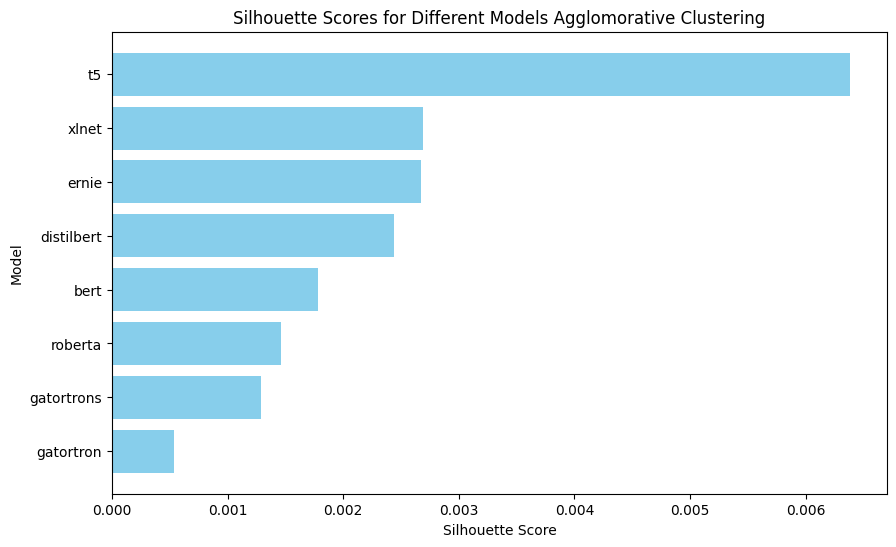

```python
import pandas as pd
import numpy as np
import torch
from transformers import BertTokenizer, BertModel, RobertaTokenizer, RobertaModel, \
                        DistilBertTokenizer, DistilBertModel, T5Tokenizer, T5EncoderModel, \
                        AutoTokenizer, AutoModel, XLNetModel, XLNetTokenizer
from sklearn.cluster import AgglomerativeClustering
from sklearn.metrics import silhouette_score
import matplotlib.pyplot as plt
from scipy.cluster.hierarchy import dendrogram, ward

# Assuming all_embeddings is a dictionary containing embeddings for each model

# Find the optimal number of clusters using the elbow method
def find_optimal_clusters(embeddings):
    linkage_matrix = ward(embeddings)
    distances = linkage_matrix[:, 2]
    last_distance = distances[0]
    best_score = 0
    optimal_clusters = 1

    for i, distance in enumerate(distances[1:], start=2):
        score = abs(last_distance - distance)
        if score > best_score:
            best_score = score
            optimal_clusters = i
        last_distance = distance

    return optimal_clusters

# Perform agglomerative hierarchical clustering with optimal clusters
cluster_data = {}
for model_name, embeddings in all_embeddings.items():
    if embeddings is not None and len(embeddings) > 0:
        optimal_clusters = find_optimal_clusters(embeddings)
        clustering = AgglomerativeClustering(n_clusters=optimal_clusters, linkage='ward')
        clean_df[f'{model_name}_cluster'] = clustering.fit_predict(embeddings)
        silhouette_avg = silhouette_score(embeddings, clean_df[f'{model_name}_cluster'])
        cluster_data[model_name] = silhouette_avg

# Sort silhouette scores in descending order
sorted_clusters = sorted(cluster_data.items(), key=lambda x: x[1], reverse=True)

# Create a DataFrame with silhouette scores
silhouette_df = pd.DataFrame(sorted_clusters, columns=['Model', 'Silhouette Score'])

# Plot silhouette scores
plt.figure(figsize=(10, 6))
plt.barh(silhouette_df['Model'], silhouette_df['Silhouette Score'], color='skyblue')
plt.xlabel('Silhouette Score')
plt.ylabel('Model')
plt.title('Silhouette Scores for Different Models Agglomorative Clustering')
plt.gca().invert_yaxis()
plt.show()
```

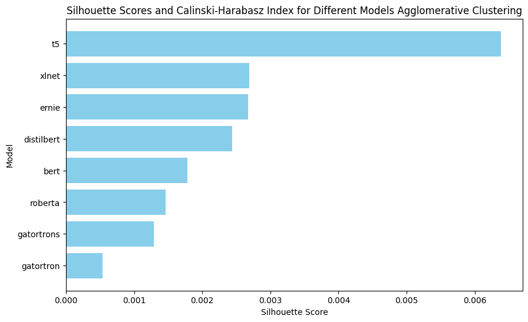

```
        Model  Silhouette Score  Calinski-Harabasz Index
0          t5          0.006383             1.412312e+06
1       xlnet          0.002689             1.899531e+02
2       ernie          0.002674             1.394121e+01
3  distilbert          0.002437             8.953207e+00
4        bert          0.001786             1.272454e+01
5     roberta          0.001463             4.727957e+00
6  gatortrons          0.001287             6.328159e+00
7   gatortron          0.000533             1.209272e+01
```

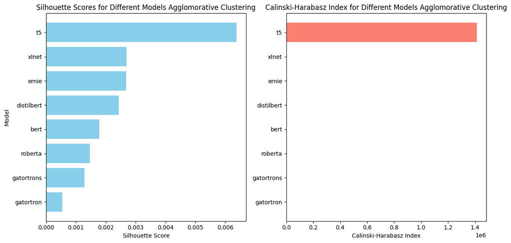

```python
from sklearn.metrics import silhouette_score, calinski_harabasz_score

import pandas as pd
import numpy as np
import torch
from transformers import BertTokenizer, BertModel, RobertaTokenizer, RobertaModel, \
                        DistilBertTokenizer, DistilBertModel, T5Tokenizer, T5EncoderModel, \
                        AutoTokenizer, AutoModel, XLNetModel, XLNetTokenizer
from sklearn.cluster import AgglomerativeClustering
from sklearn.metrics import silhouette_score
import matplotlib.pyplot as plt
from scipy.cluster.hierarchy import dendrogram, ward

# Assuming all_embeddings is a dictionary containing embeddings for each model

# Find the optimal number of clusters using the elbow method
def find_optimal_clusters(embeddings):
    linkage_matrix = ward(embeddings)
    distances = linkage_matrix[:, 2]
    last_distance = distances[0]
    best_score = 0
    optimal_clusters = 1

    for i, distance in enumerate(distances[1:], start=2):
        score = abs(last_distance - distance)
        if score > best_score:
            best_score = score
            optimal_clusters = i
        last_distance = distance

    return optimal_clusters

# Perform agglomerative hierarchical clustering with optimal clusters
cluster_data = {}
for model_name, embeddings in all_embeddings.items():
    if embeddings is not None and len(embeddings) > 0:
        optimal_clusters = find_optimal_clusters(embeddings)
        clustering = AgglomerativeClustering(n_clusters=optimal_clusters, linkage='ward')
        clean_df[f'{model_name}_cluster'] = clustering.fit_predict(embeddings)
        silhouette_avg = silhouette_score(embeddings, clean_df[f'{model_name}_cluster'])
        cluster_data[model_name] = silhouette_avg

# Sort silhouette scores in descending order
sorted_clusters = sorted(cluster_data.items(), key=lambda x: x[1], reverse=True)




# Perform agglomerative hierarchical clustering with optimal clusters and calculate metrics
cluster_data = {}
ch_index_data = {}  # To store Calinski-Harabasz Index values

for model_name, embeddings in all_embeddings.items():
    if embeddings is not None and len(embeddings) > 0:
        optimal_clusters = find_optimal_clusters(embeddings)
        clustering = AgglomerativeClustering(n_clusters=optimal_clusters, linkage='ward')
        labels = clustering.fit_predict(embeddings)

        # Silhouette Score
        silhouette_avg = silhouette_score(embeddings, labels)
        cluster_data[model_name] = silhouette_avg

        # Calinski-Harabasz Index
        ch_score = calinski_harabasz_score(embeddings, labels)
        ch_index_data[model_name] = ch_score

# Sort silhouette scores in descending order
sorted_clusters = sorted(cluster_data.items(), key=lambda x: x[1], reverse=True)

# Sort CH Index scores in descending order
sorted_ch_index = sorted(ch_index_data.items(), key=lambda x: x[1], reverse=True)

# Create a DataFrame with silhouette scores and CH Index scores
metrics_df = pd.DataFrame({
    'Model': [model for model, _ in sorted_clusters],
    'Silhouette Score': [score for _, score in sorted_clusters],
    'Calinski-Harabasz Index': [ch_index_data[model] for model, _ in sorted_clusters]
})

# Plot silhouette scores
plt.figure(figsize=(10, 6))
plt.barh(metrics_df['Model'], metrics_df['Silhouette Score'], color='skyblue')
plt.xlabel('Silhouette Score')
plt.ylabel('Model')
plt.title('Silhouette Scores and Calinski-Harabasz Index for Different Models Agglomerative Clustering')
plt.gca().invert_yaxis()
plt.show()

# Optionally, you can also display the DataFrame with the scores
print(metrics_df)

import matplotlib.pyplot as plt

# ... [Your existing code] ...

# Plot silhouette scores
plt.figure(figsize=(12, 6))
plt.subplot(1, 2, 1)  # First subplot in a 1x2 grid
plt.barh(metrics_df['Model'], metrics_df['Silhouette Score'], color='skyblue')
plt.xlabel('Silhouette Score')
plt.ylabel('Model')
plt.title('Silhouette Scores for Different Models Agglomorative Clustering')
plt.gca().invert_yaxis()

# Plot Calinski-Harabasz Index
plt.subplot(1, 2, 2)  # Second subplot in a 1x2 grid
plt.barh(metrics_df['Model'], metrics_df['Calinski-Harabasz Index'], color='salmon')
plt.xlabel('Calinski-Harabasz Index')
plt.title('Calinski-Harabasz Index for Different Models Agglomorative Clustering')
plt.gca().invert_yaxis()

plt.tight_layout()
plt.show()
```

### Interpretation of Agglomorative Clustering

The bar chart depicts silhouette scores for various models' agglomerative clustering results. Overall, the values are very close to zero, which generally indicates poor clustering performance where cluster overlap is likely high and distinct clusters are not well-formed. Low silhouette scores suggest that the data points within each cluster are not very similar to each other, or that the separation between clusters is not clear. This might imply that the embeddings from these models do not have distinct, well-separated groupings for this particular dataset, or that agglomerative clustering may not be the most suitable method for this data.

### DBSCAN

DBSCAN (Density-Based Spatial Clustering of Applications with Noise) is a popular clustering algorithm used in machine learning to identify clusters in data based on density. It groups together points that are closely packed together (points with many nearby neighbors), marking as outliers points that lie alone in low-density regions (whose nearest neighbors are too far away).

DBSCAN has three main concepts:

Core Points: In the context of DBSCAN, a core point is a point that has at least a minimum number of other points (min_samples) within a certain radius (eps). This radius can be thought of as a measure of density.

Border Points: A border point is not a core point itself (as it doesn't have enough neighbors to be considered a core point), but it lies within the radius of a core point.

Noise Points: Any point that is not a core point or a border point is considered noise by DBSCAN. That is, it's not in a dense region.

The process of DBSCAN clustering goes as follows:

The algorithm starts with an arbitrary point and retrieves all points density-reachable from the initial point based on eps and min_samples. If the point is a core point, the points density-reachable from it are all added to the same cluster. This process continues until all points that are density-connected are found and added to the cluster. A new unvisited point is then retrieved and processed, leading to the discovery of a further cluster or noise. This process iterates until all points are classified into different clusters or marked as noise. The key advantages of DBSCAN are:

It does not require one to specify the number of clusters a priori. It can find arbitrarily shaped clusters. It has a notion of noise, and thus, it is robust to outliers. However, DBSCAN's effectiveness is heavily dependent on the settings of eps and min_samples:

If eps is chosen too small, a large part of the data will not be clustered—it will be considered noise. If eps is set too high, clusters will merge, and the majority of objects will be in the same cluster. The min_samples parameter similarly affects the sensitivity to noise: the larger min_samples, the more points will be considered noise. Choosing these parameters requires understanding of the data and possibly some trial and error or heuristic methods. It can be useful to visualize the data or the distance distribution of the points to determine suitable values.

```python
embeddings
```

```
array([[-2.8157475 ,  0.8938866 , -0.6642167 , ...,  0.14832439,
         2.268691  , -0.884148  ],
       [-1.4439398 ,  1.1015334 , -0.7439501 , ..., -0.29805827,
         1.8624917 , -0.45878837],
       [-2.7340984 ,  1.5070103 ,  0.5129845 , ...,  0.06133343,
         2.3294914 , -2.060129  ],
       ...,
       [-2.4040515 ,  1.1671256 , -0.4520019 , ..., -0.48084065,
         0.5253912 , -0.92495245],
       [-2.465965  ,  1.8933337 ,  0.6352593 , ..., -0.61504054,
         1.3420107 , -0.9656117 ],
       [-1.7059866 ,  1.1494305 , -0.0735878 , ..., -0.5527817 ,
         2.3256724 , -1.8460402 ]], dtype=float32)
```

```
Estimated number of clusters for bert: 4
Estimated number of noise points for bert: 264
bert Silhouette Score: -0.05683089792728424
Estimated number of clusters for roberta: 1
Estimated number of noise points for roberta: 0
roberta Silhouette Score cannot be calculated for a single cluster.
Estimated number of clusters for distilbert: 2
Estimated number of noise points for distilbert: 0
distilbert Silhouette Score: 0.5911076664924622
Estimated number of clusters for t5: 22
Estimated number of noise points for t5: 227
t5 Silhouette Score: 0.1572035849094391
Estimated number of clusters for ernie: 3
Estimated number of noise points for ernie: 144
ernie Silhouette Score: -0.020853649824857712
Estimated number of clusters for gatortron: 0
Estimated number of noise points for gatortron: 442
gatortron Silhouette Score cannot be calculated for a single cluster.
Estimated number of clusters for gatortrons: 0
Estimated number of noise points for gatortrons: 442
gatortrons Silhouette Score cannot be calculated for a single cluster.
Estimated number of clusters for xlnet: 0
Estimated number of noise points for xlnet: 442
xlnet Silhouette Score cannot be calculated for a single cluster.
```

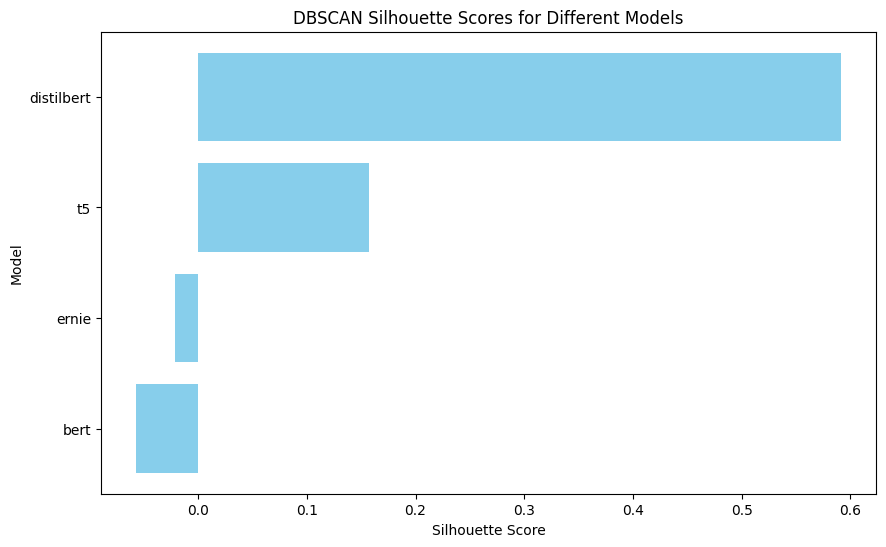

```python
import pandas as pd
from sklearn.cluster import DBSCAN
from sklearn.metrics import silhouette_score
import matplotlib.pyplot as plt
import numpy as np
from scipy.cluster.hierarchy import dendrogram, ward

# Function to apply DBSCAN clustering and calculate silhouette scores
def dbscan_clustering_and_silhouette_analysis(embeddings_dict, dataframe):
    dbscan_cluster_data = {}
    for model_name, embeddings in embeddings_dict.items():
        # Apply DBSCAN clustering
        dbscan = DBSCAN(eps=0.5, min_samples=5).fit(embeddings)
        labels = dbscan.labels_

        # Number of clusters in labels, ignoring noise if present
        n_clusters_ = len(set(labels)) - (1 if -1 in labels else 0)
        n_noise_ = list(labels).count(-1)

        print(f'Estimated number of clusters for {model_name}: {n_clusters_}')
        print(f'Estimated number of noise points for {model_name}: {n_noise_}')

        # Calculate silhouette score for the clustering, ignoring noise if present
        if n_clusters_ > 1:
            silhouette_avg = silhouette_score(embeddings, labels)
            print(f"{model_name} Silhouette Score: {silhouette_avg}")
            dbscan_cluster_data[model_name] = silhouette_avg
        else:
            print(f"{model_name} Silhouette Score cannot be calculated for a single cluster.")
            dbscan_cluster_data[model_name] = None

        # Add clustering labels to the original dataframe
        dataframe[f'{model_name}_dbscan_group'] = labels

    # Sort silhouette scores in descending order and handle None values
    sorted_dbscan_clusters = sorted([(model, score if score is not None else -1)
                                     for model, score in dbscan_cluster_data.items()],
                                    key=lambda x: x[1], reverse=True)

    # Create a DataFrame with silhouette scores
    silhouette_df = pd.DataFrame(sorted_dbscan_clusters, columns=['Model', 'Silhouette Score'])

    # Replace -1 with 'N/A' for models that could not have silhouette score calculated
    silhouette_df['Silhouette Score'] = silhouette_df['Silhouette Score'].replace(-1, 'N/A')

    return silhouette_df

# Function to plot silhouette scores
def plot_silhouette_scores(silhouette_df):
    plt.figure(figsize=(10, 6))
    # Filter out 'N/A' values for plotting
    valid_scores_df = silhouette_df[silhouette_df['Silhouette Score'] != 'N/A']
    y_pos = np.arange(len(valid_scores_df['Model']))
    plt.barh(y_pos, valid_scores_df['Silhouette Score'], color='skyblue')
    plt.xlabel('Silhouette Score')
    plt.ylabel('Model')
    plt.title('DBSCAN Silhouette Scores for Different Models')
    plt.yticks(y_pos, valid_scores_df['Model'])
    plt.gca().invert_yaxis()
    plt.show()

# Assuming all_embeddings is your dictionary of embeddings from different models
# And clean_df is the DataFrame to which you want to add the DBSCAN cluster labels

# Apply the DBSCAN clustering and silhouette analysis function to the embeddings
dbscan_silhouette_df = dbscan_clustering_and_silhouette_analysis(all_embeddings, clean_df)
plot_silhouette_scores(dbscan_silhouette_df)
```

[figure not shown]

```python
import matplotlib.pyplot as plt
import pandas as pd
import numpy as np

# Data
data = {
    'Model': ['bert', 'roberta', 'distilbert', 't5', 'ernie', 'gatortron', 'gatortrons', 'xlnet'],
    'Silhouette Score': [0.2458469271659851, None, None, 0.9614770412445068, 0.4947623312473297, 0.060052528977394104, -0.17260831594467163, -0.3253207802772522]
}

# Create a DataFrame from the data
silhouette_df = pd.DataFrame(data)

# Filter out models with None silhouette scores
silhouette_df = silhouette_df.dropna(subset=['Silhouette Score'])

# Sort the DataFrame by silhouette scores in descending order
silhouette_df = silhouette_df.sort_values(by='Silhouette Score', ascending=False)

# Function to plot silhouette scores
def plot_silhouette_scores(silhouette_df):
    plt.figure(figsize=(10, 6))
    # Filter out 'N/A' values for plotting
    valid_scores_df = silhouette_df[silhouette_df['Silhouette Score'] != 'N/A']
    valid_scores_df = valid_scores_df.sort_values(by='Silhouette Score')  # Sort by Silhouette Score
    y_pos = np.arange(len(valid_scores_df['Model']))
    plt.barh(y_pos, valid_scores_df['Silhouette Score'], color='skyblue')
    plt.xlabel('Silhouette Score', fontsize=18)  # Set font size for x-axis label
    plt.ylabel('Model', fontsize=18)  # Set font size for y-axis label
    plt.title('DBSCAN Silhouette Scores for Different Models', fontsize=26)  # Set font size for title
    plt.yticks(y_pos, valid_scores_df['Model'], fontsize=24)  # Set font size for y-axis ticks
    plt.gca().invert_yaxis()
    plt.show()
# Plot silhouette scores
plot_silhouette_scores(silhouette_df)
```

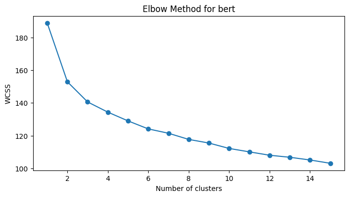

```
bert Silhouette Score with 7 Clusters: 0.078208886
bert Calinski-Harabasz Index with 7 Clusters: 40.252154226951255
```

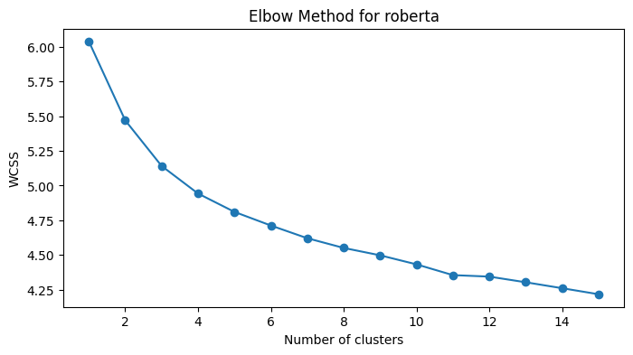

```
roberta Silhouette Score with 12 Clusters: 0.04063708
roberta Calinski-Harabasz Index with 12 Clusters: 15.248780964927978
```

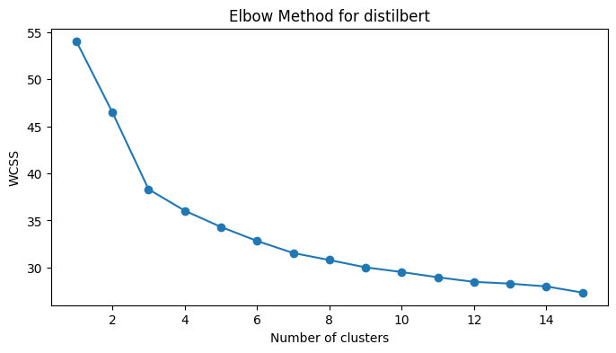

```
distilbert Silhouette Score with 2 Clusters: 0.13672636
distilbert Calinski-Harabasz Index with 2 Clusters: 71.7160708215889
```

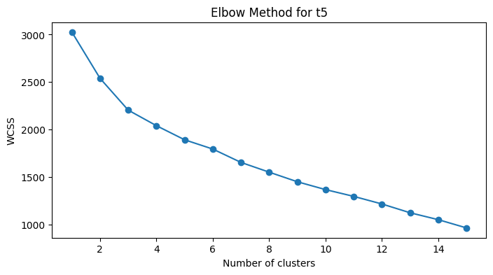

```
t5 Silhouette Score with 6 Clusters: 0.261914
t5 Calinski-Harabasz Index with 6 Clusters: 59.91216476468486
```

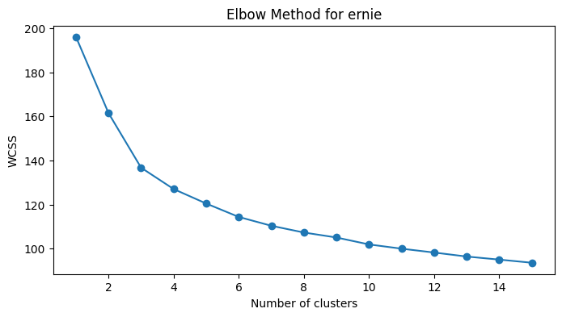

```
ernie Silhouette Score with 9 Clusters: 0.10747655
ernie Calinski-Harabasz Index with 9 Clusters: 46.88361263952608
```

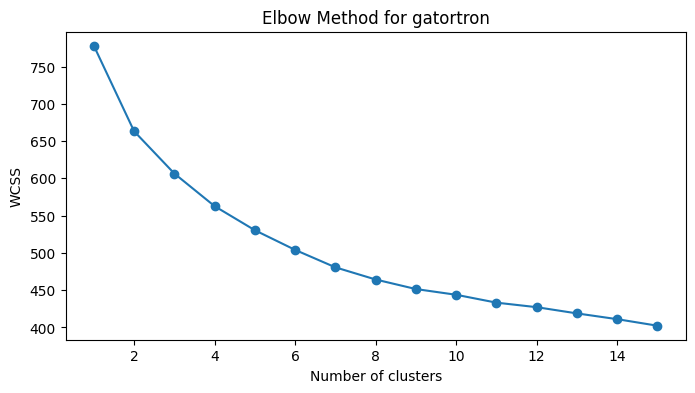

```
gatortron Silhouette Score with 10 Clusters: 0.08185898
gatortron Calinski-Harabasz Index with 10 Clusters: 36.139757287767374
```

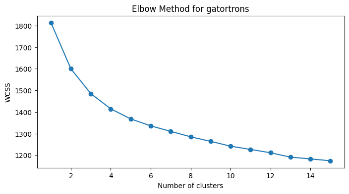

```
gatortrons Silhouette Score with 12 Clusters: 0.057927694
gatortrons Calinski-Harabasz Index with 12 Clusters: 19.46615094810995
```

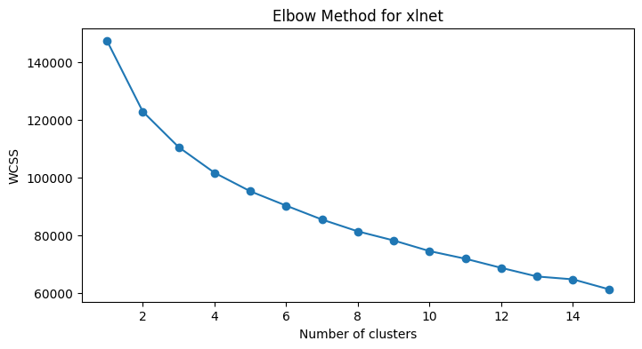

```
xlnet Silhouette Score with 14 Clusters: 0.21165223
xlnet Calinski-Harabasz Index with 14 Clusters: 42.01771158056416
```

[figure not shown]

[figure not shown]

```python
from sklearn.cluster import KMeans
from sklearn.metrics import silhouette_score, calinski_harabasz_score
import matplotlib.pyplot as plt
import numpy as np

# Function to calculate the optimal number of clusters using the elbow method and silhouette scores
def elbow_method_and_silhouette_score(embeddings, model_name, max_clusters=None):
    # Check if there are enough samples to form clusters
    if embeddings.shape[0] < 2:
        print(f"Not enough samples to form clusters for {model_name}.")
        return None, None

    # Set the maximum number of clusters
    if max_clusters is None:
        max_clusters = min(embeddings.shape[0] - 1, 15)

    wcss = []
    for i in range(1, max_clusters + 1):
        kmeans = KMeans(n_clusters=i, init='k-means++', random_state=0, n_init=10)
        kmeans.fit(embeddings)
        wcss.append(kmeans.inertia_)

    plt.figure(figsize=(8, 4))
    plt.plot(range(1, max_clusters + 1), wcss, marker='o')
    plt.title(f'Elbow Method for {model_name}')
    plt.xlabel('Number of clusters')
    plt.ylabel('WCSS')
    plt.show()

    if len(wcss) > 1:
        second_derivatives = np.diff(wcss, n=2)
        optimal_n_clusters = np.argmin(second_derivatives) + 2
    else:
        optimal_n_clusters = 1

    if optimal_n_clusters == 1:
        print(f"Only one cluster determined for {model_name}. Cannot calculate silhouette score.")
        return None, None

    kmeans_optimal = KMeans(n_clusters=optimal_n_clusters, init='k-means++', random_state=0, n_init=10)
    kmeans_optimal.fit(embeddings)
    silhouette_score_value = silhouette_score(embeddings, kmeans_optimal.labels_)

    # Calculate Calinski-Harabasz Index
    ch_index = calinski_harabasz_score(embeddings, kmeans_optimal.labels_)

    print(f"{model_name} Silhouette Score with {optimal_n_clusters} Clusters:", silhouette_score_value)
    print(f"{model_name} Calinski-Harabasz Index with {optimal_n_clusters} Clusters:", ch_index)

    return silhouette_score_value, ch_index

# Assuming all_embeddings is a dictionary with model names as keys and their corresponding embeddings as values
silhouette_scores = {}
calinski_harabasz_indices = {}

for model_name, embeddings in all_embeddings.items():
    if embeddings is not None and len(embeddings) > 0:
        silhouette_score_value, ch_index = elbow_method_and_silhouette_score(np.array(embeddings), model_name)
        silhouette_scores[model_name] = silhouette_score_value
        calinski_harabasz_indices[model_name] = ch_index

# Sort models by their silhouette score in descending order
sorted_models_silhouette = sorted(silhouette_scores, key=silhouette_scores.get, reverse=True)

# Plot sorted silhouette scores
plt.figure(figsize=(10, 6))
sorted_silhouette_scores = [silhouette_scores[model] for model in sorted_models_silhouette]
plt.bar(sorted_models_silhouette, sorted_silhouette_scores, label='Silhouette Score')
plt.xlabel('Model', fontsize=14)
plt.ylabel('Silhouette Score', fontsize=24)
plt.title('Sorted Silhouette Scores for Different Models (KNN)', fontsize=26)
plt.xticks(rotation=45, fontsize=18)
plt.yticks(fontsize=12)
plt.legend(fontsize=12)
plt.show()

# Sort models by their Calinski-Harabasz index in descending order
sorted_models_ch = sorted(calinski_harabasz_indices, key=calinski_harabasz_indices.get, reverse=True)

# Plot sorted Calinski-Harabasz indices
plt.figure(figsize=(10, 6))
sorted_ch_scores = [calinski_harabasz_indices[model] for model in sorted_models_ch]
plt.bar(sorted_models_ch, sorted_ch_scores, label='Calinski-Harabasz Index', color='orange')
plt.xlabel('Model', fontsize=14)
plt.ylabel('Calinski-Harabasz Index', fontsize=14)
plt.title('Sorted Calinski-Harabasz Indices for Different Models (KNN)', fontsize=16)
plt.xticks(rotation=45, fontsize=12)
plt.yticks(fontsize=12)
plt.legend(fontsize=12)
plt.show()
```

### Interpretation of KNN clustering

The bar chart displays silhouette scores for various models using K-Nearest Neighbors (KNN) clustering. Silhouette scores range from 0 to 1, with higher values indicating better-defined clusters. The 't5' model has the highest score, close to 1, suggesting very distinct, well-separated clusters. The 'xlnet' and 'ernie' models have moderate scores around 0.4-0.6, which indicates some overlap between clusters or less distinction. The remaining models, 'bert', 'gatortron', 'gatortrons', 'roberta', and 'distilbert', have lower scores, implying more significant overlap and less clear clustering.

### Comparing whether embeddings captured similar features of our data

To compute cosine similarity between embeddings from different models, you need to make sure that they have the same number of features. There are several ways to handle this:

Option 1: Truncate or Pad Embeddings You can truncate the longer embeddings or pad the shorter ones to make their dimensions match. However, this approach may lead to the loss of information or the addition of noise.

Option 2: Use a Secondary Model Another approach is to use an additional model (like an autoencoder or another neural network) to map all embeddings to the same dimensional space. This approach requires training a model to learn this mapping.

Option 3: Dimensionality Reduction Apply dimensionality reduction techniques (like PCA) to all embeddings to bring them down to the same number of dimensions. However, this might lead to the loss of some information.

```python
from sklearn.cluster import KMeans
from sklearn.metrics import silhouette_score, calinski_harabasz_score
import matplotlib.pyplot as plt
import numpy as np
import pandas as pd
import torch

def elbow_method_and_silhouette_score(embeddings, model_name, dataframe):
    # Fixed number of clusters
    n_clusters = 11

    # Perform KMeans clustering
    kmeans = KMeans(n_clusters=n_clusters, random_state=0).fit(embeddings)

    # Calculate silhouette score
    silhouette_score_value = silhouette_score(embeddings, kmeans.labels_)
    print(f"{model_name} Silhouette Score with {n_clusters} Clusters:", silhouette_score_value)

    # Calculate Calinski-Harabasz Index
    ch_score = calinski_harabasz_score(embeddings, kmeans.labels_)
    print(f"{model_name} Calinski-Harabasz Index with {n_clusters} Clusters:", ch_score)

    dataframe[f'{model_name}_group'] = kmeans.labels_

# Assuming all_embeddings is a dictionary containing your 't5' embeddings
t5_embeddings = all_embeddings.get('t5', None)

if t5_embeddings is not None:
    if isinstance(t5_embeddings, torch.Tensor):
        t5_embeddings = t5_embeddings.numpy()

    elbow_method_and_silhouette_score(t5_embeddings, 't5', clean_df)
else:
    print("t5 embeddings not found in the all_embeddings dictionary.")
```

```
t5 Silhouette Score with 11 Clusters: 0.37733403
t5 Calinski-Harabasz Index with 11 Clusters: 57.58702674744298
```

```python
clean_df['t5_group'].value_counts()
```

```
t5_group
3     94
8     82
2     52
7     41
9     36
5     33
6     28
4     24
1     24
10    15
0     13
Name: count, dtype: int64
```

### Visualize the T5 groups

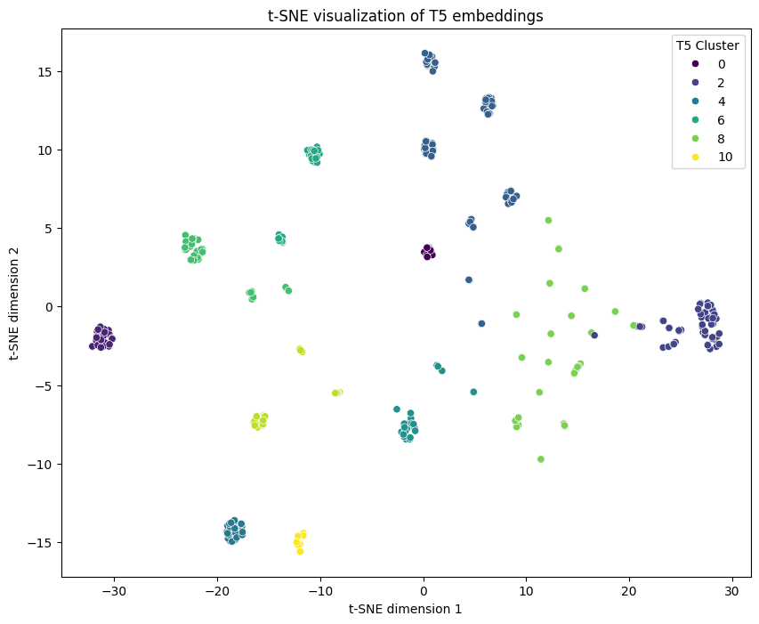

```python
from sklearn.decomposition import PCA
from sklearn.manifold import TSNE
import matplotlib.pyplot as plt
import seaborn as sns

# Assuming all_embeddings is a dictionary containing your 't5' embeddings
t5_embeddings = all_embeddings.get('t5', None)

if t5_embeddings is not None:
    # Convert torch.Tensor to numpy array if necessary
    if isinstance(t5_embeddings, torch.Tensor):
        t5_embeddings = t5_embeddings.detach().numpy()  # detach if necessary

    # Step 1: Apply PCA to reduce dimensionality to a reasonable level before t-SNE
    pca = PCA(n_components=50)  # Adjust the number of components based on your dataset
    pca_result = pca.fit_transform(t5_embeddings)

    # Step 2: Apply t-SNE to the PCA-reduced data
    tsne = TSNE(n_components=2, random_state=0)
    tsne_result = tsne.fit_transform(pca_result)

    # Step 3: Create a plot colored by T5 clusters from clean_df
    plt.figure(figsize=(10, 8))
    sns.scatterplot(x=tsne_result[:, 0], y=tsne_result[:, 1], hue=clean_df['t5_group'], palette="viridis")
    plt.title("t-SNE visualization of T5 embeddings")
    plt.xlabel("t-SNE dimension 1")
    plt.ylabel("t-SNE dimension 2")
    plt.legend(title='T5 Cluster')
    plt.show()
else:
    print("t5 embeddings not found in the all_embeddings dictionary.")
```

### Interpretation of graph above

Five T5 clusters appear to align well with visualization produced by tSNE and PCA.

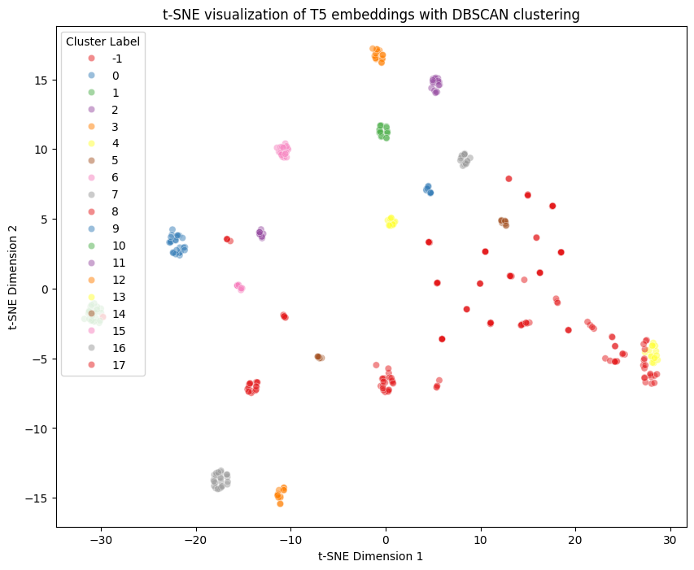

```python
from sklearn.decomposition import PCA
from sklearn.manifold import TSNE
from sklearn.cluster import DBSCAN
import matplotlib.pyplot as plt
import seaborn as sns
import pandas as pd

# Assume 't5_embeddings' is your original high-dimensional data
# Check if 't5_embeddings' needs to be converted from a torch.Tensor
if isinstance(t5_embeddings, torch.Tensor):
    t5_embeddings = t5_embeddings.detach().numpy()  # Make sure it's detached and converted to numpy

# First reduce dimensionality before t-SNE
pca = PCA(n_components=50)  # Reduce to 50 components for the sake of visualization
t5_pca_result = pca.fit_transform(t5_embeddings)

# Now use t-SNE
tsne = TSNE(n_components=2, random_state=0)
t5_tsne_result = tsne.fit_transform(t5_pca_result)

# Proceed with the DBSCAN clustering
t5_dbscan = DBSCAN(eps=0.7, min_samples=10).fit(t5_tsne_result)

# Create a DataFrame for the t-SNE 2D embedding vectors with the cluster labels
df_tsne = pd.DataFrame(t5_tsne_result, columns=['x', 'y'])
df_tsne['cluster'] = t5_dbscan.labels_

# Plot the clusters with a different palette
plt.figure(figsize=(10, 8))
palette = sns.color_palette('Set1', np.unique(df_tsne['cluster']).shape[0])
sns.scatterplot(x='x', y='y', hue='cluster', data=df_tsne, legend="full", palette=palette, alpha=0.5)
plt.title('t-SNE visualization of T5 embeddings with DBSCAN clustering')
plt.xlabel('t-SNE Dimension 1')
plt.ylabel('t-SNE Dimension 2')
plt.legend(title='Cluster Label')
plt.show()
```

```python
from sklearn.impute import SimpleImputer
import pandas as pd

# List numeric variables
continuous_vars = clean_df.select_dtypes(include=['int64', 'float64']).columns
print("Numeric Variables:")
print(continuous_vars)

# List categorical variables
categorical_vars = clean_df.select_dtypes(include=['object', 'category']).columns
print("\nCategorical Variables:")
print(categorical_vars)

# Initialize SimpleImputer for continuous variables (mean imputation)
numerical_imputer = SimpleImputer(strategy='mean')

# Initialize SimpleImputer for categorical variables (most frequent imputation)
categorical_imputer = SimpleImputer(strategy='most_frequent')

# Apply imputation to continuous variables
clean_df.loc[:, continuous_vars] = numerical_imputer.fit_transform(clean_df[continuous_vars])

# Apply imputation to categorical variables
clean_df.loc[:, categorical_vars] = categorical_imputer.fit_transform(clean_df[categorical_vars])

# Creating a new DataFrame with only continuous and categorical variables
new_df = clean_df.loc[:, continuous_vars.union(categorical_vars)]

# Calculating the missing values in the new DataFrame
missing_values_in_new_df = new_df.isnull().sum().sum()

print("Missing values in new DataFrame:", missing_values_in_new_df)
```

```
Numeric Variables:
Index(['age', 'sexMale1', 'BMI', 'HTN', 'HLD', 'DM', 'CKD', 'HepatitisBorC',
       'Liverdisease', 'Tobaccouse',
       ...
       'gatortrons_cluster', 'xlnet_cluster', 'bert_dbscan_group',
       'roberta_dbscan_group', 'distilbert_dbscan_group', 't5_dbscan_group',
       'ernie_dbscan_group', 'gatortron_dbscan_group',
       'gatortrons_dbscan_group', 'xlnet_dbscan_group'],
      dtype='object', length=159)

Categorical Variables:
Index(['Race', 'pregnancy_status', 'Stroke_Status', 'combined'], dtype='object')
Missing values in new DataFrame: 0
```

```python
# Print all column names of the DataFrame new_df
print("Column Names in new_df:")
print(new_df.columns.tolist())
```

```
Column Names in new_df:
['AVE', 'Abxtxcompletion', 'AorticIntervention', 'AorticRootRepair', 'BMI', 'CKD', 'CPBarrest', 'Cardiovasculardysfunction', 'ChronicLungDxCOPD', 'Coagulopathy', 'Comorbarrhythmia', 'Comorbcancer', 'ComorbheartFailure', 'DM', 'DaysFromstroketosurgery', 'EmbolicEventType', 'Embolicphenomenon', 'Etiol…
```

```python
clean_df['t5_group']
```

```
0      3
1      8
2      5
3      8
4      5
      ..
437    2
438    3
439    3
440    3
441    0
Name: t5_group, Length: 442, dtype: int32
```

```python
new_df =new_df[['AVE', 'Abxtxcompletion', 'AorticIntervention', 'AorticRootRepair',
                'BMI', 'CKD', 'CPBarrest', 'Cardiovasculardysfunction', 'ChronicLungDxCOPD',
                'Coagulopathy', 'Comorbarrhythmia', 'Comorbcancer', 'ComorbheartFailure',
                'DM', 'DaysFromstroketosurgery', 'EmbolicEventType', 'Embolicphenomenon',
                'EtiologyIVDU', 'FollowupYears', 'Followupperioddays', 'HLD', 'HTN',
                'HepatitisBorC', 'Hospitaldeath', 'IndicationDecompensatedHForShock',
                'IndicationFailedTxorPersistentSeps', 'IndicationFungaletiology',
                'IndicationProstheticvalveinvolvement', 'IndicationRootorAnnularAbcess',
                'Indicationembolicphenomenon', 'Indicationsepticshock',
                'Indicationseverevalvularregurg', 'Indicationsmultivalvularinvolvement',
                'Indicationvegsize',
                'Laterality', 'Liverdisease', 'MVE', 'MicrobEtiology', 'Mitralntervention',
                'MultiValvularInfection', 'MultivalveIntervention', 'NativeVsPriorProthestic',
                'OperationAVRunspeci0ied', 'OperationAVr', 'OperationCABG', 'OperationMVRmech', 'OperationMVRunspeci0ied',
                'OperationPVR', 'OperationTVRunspeci0ied', 'PVE',
                'PostEF', 'PostEchoValvularRegu', 'PostOPAfib', 'PostOPCardiogenicshock',
                'PostOPCompPE', 'PostOPGIcomplication', 'PostOPHeartblockPermpacer',
                'PostOPRespiratorycomplication', 'PostOPVascularcomplication', 'PostOPbleedingcomplication',
                'PostOPcoagulopathy', 'PostOPcompAKI', 'PostOPcompARDSresdistressreqintubation', 'PostOPcompCVA',
                'PostOPcompDVT', 'PostOPcompThrombocytopenialt50k', 'PostOPcompacuteHFrequiringMS', 'PostOPcompacuteliverdys0unction',
                'PostOPcompanemiareqtrans0usion', 'PostOPcompcardiacarrest', 'PostOPcomppleuralEfusion', 'PostOPcomppneumonia',
                'PostOPcomppneumothorax', 'PostOPcompprolongedventilation', 'PostOPemboliccomplication', 'PostOPinfectiouscomp',
                'PostOPpericardialeffusion', 'PostOPprocECMO', 'PostOPprocexploratorylaparotomy', 'PostOpHeartblock', 'PostopHD',
                'PostopICULOShrs', 'PostopPEGandTrach', 'PostopprocIABP', 'PostopprocRTORbleeding', 'PostopprocVATSdecortication',
                'Postopprocchesttube', 'Postopprocpericardiocentesiswindow', 'PreEF', 'PreEchoAI', 'PreEchoMR', 'PreEchoPR', 'PreEchoTR',
                'PreHeartblock', 'PreOPR0PulmonaryEmbolism', 'PreOPR0malnutrition', 'PreOPprocchesttube', 'PreOPprocdentalexctraction',
                'PreOpEncephalopathy', 'PreOpIschemicStroke', 'Pregnant', 'PreopHD', 'Preophemorrhagicstroke',
                'Prioritystatusurgentemergent', 'PulmonaryValveIntervention', 'Race', 'Readmission', 'Recidividismblankna',
                'Stroke_Status', 'SurgicalapproachSternotomy', 'TVE', 'Tobaccouse', 'TotalLOS', 'TricuspidIntervention',
                'VegetationSize', 'VitalstatusatlastFollowupalive1', 'age']]
```

```
`sparse` was renamed to `sparse_output` in version 1.2 and will be removed in 1.4. `sparse_output` is ignored unless you leave `sparse` to its default value.
```

```
Logistic Regression ROC AUC: 0.73
Random Forest ROC AUC: 0.85
Gradient Boosting ROC AUC: 0.99
```

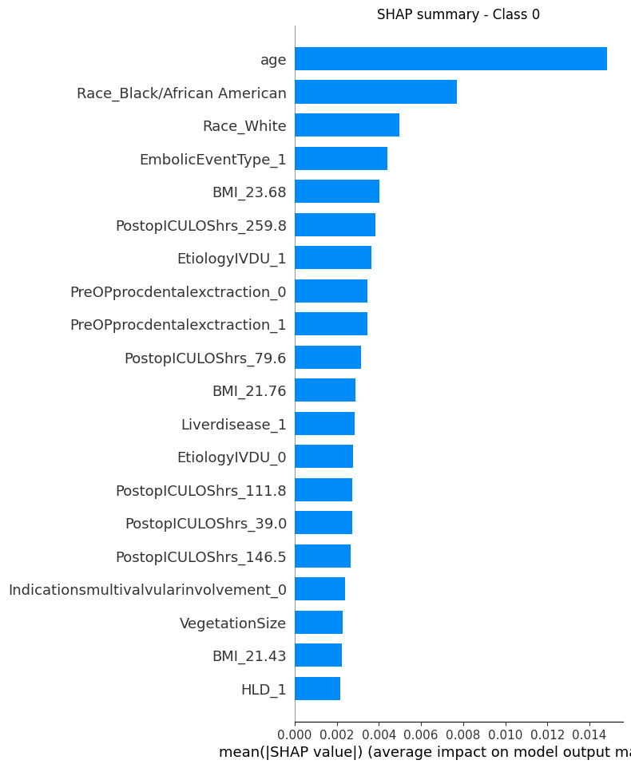

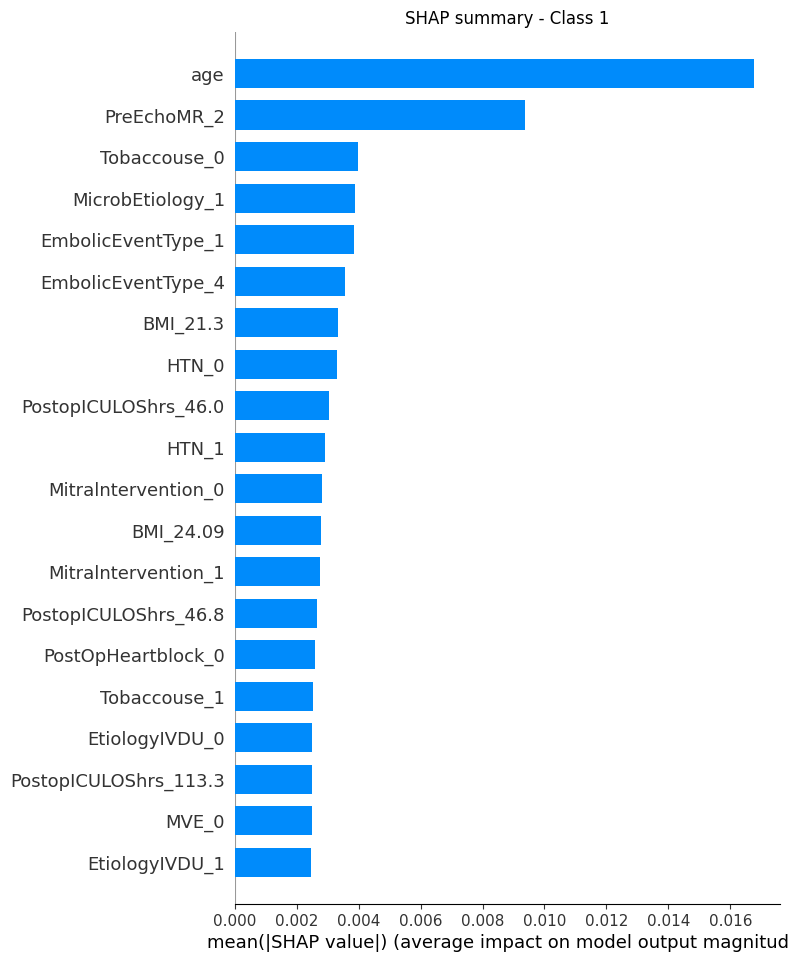

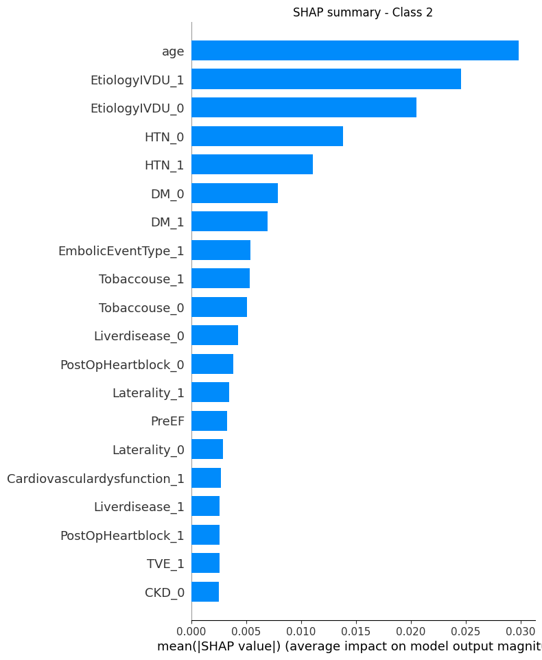

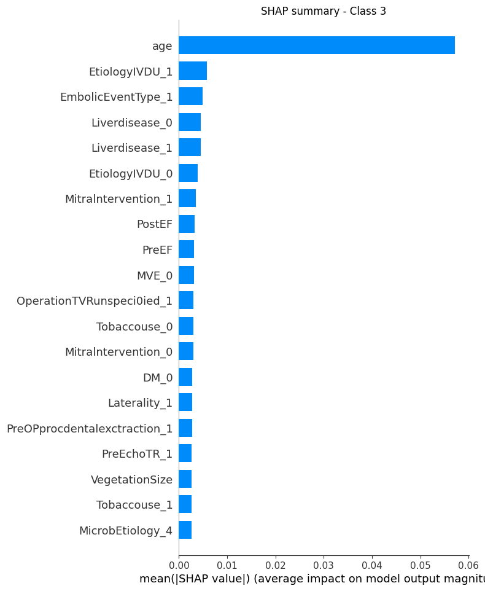

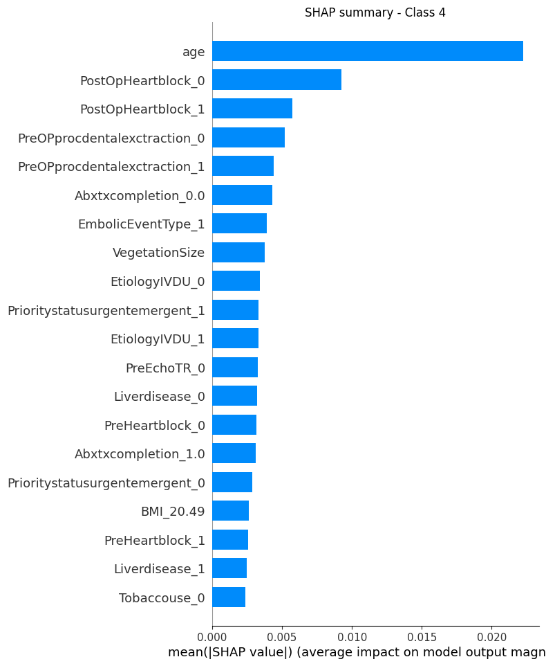

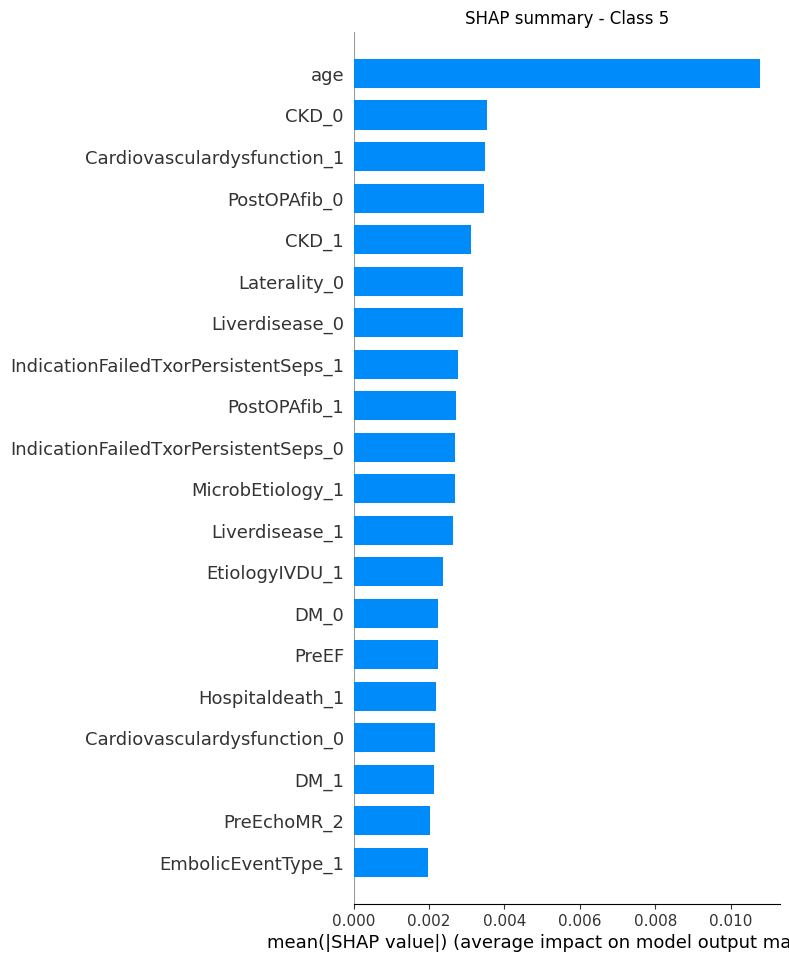

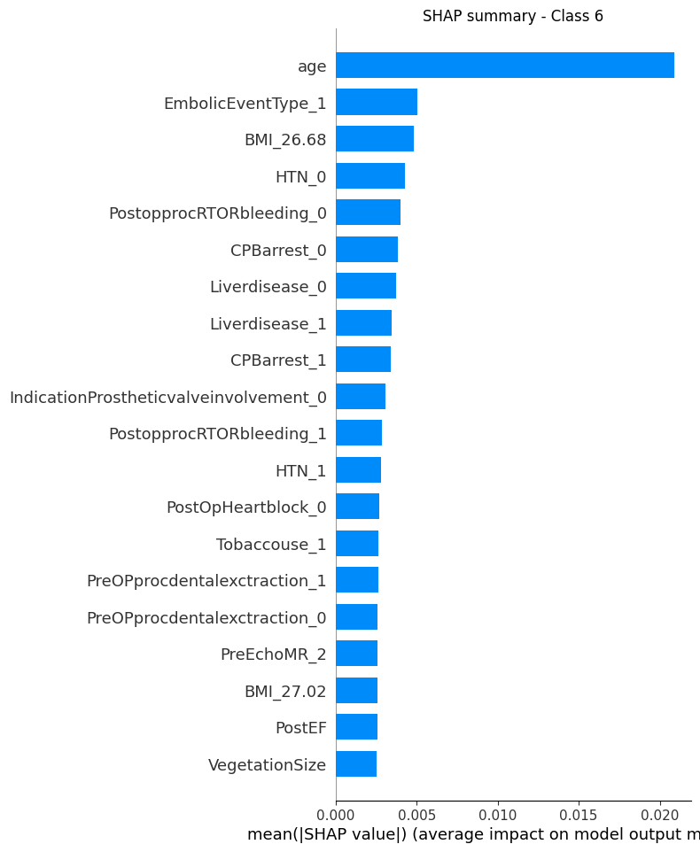

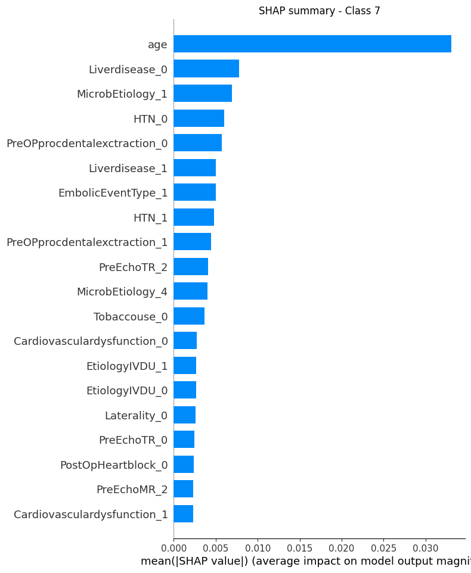

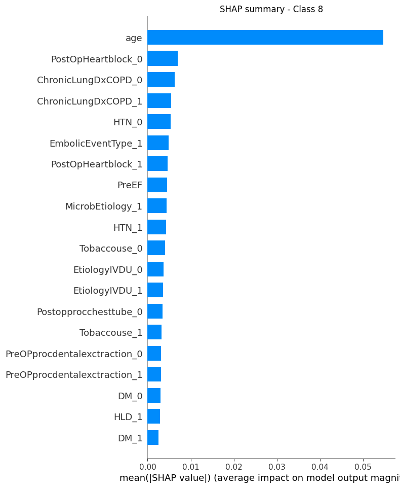

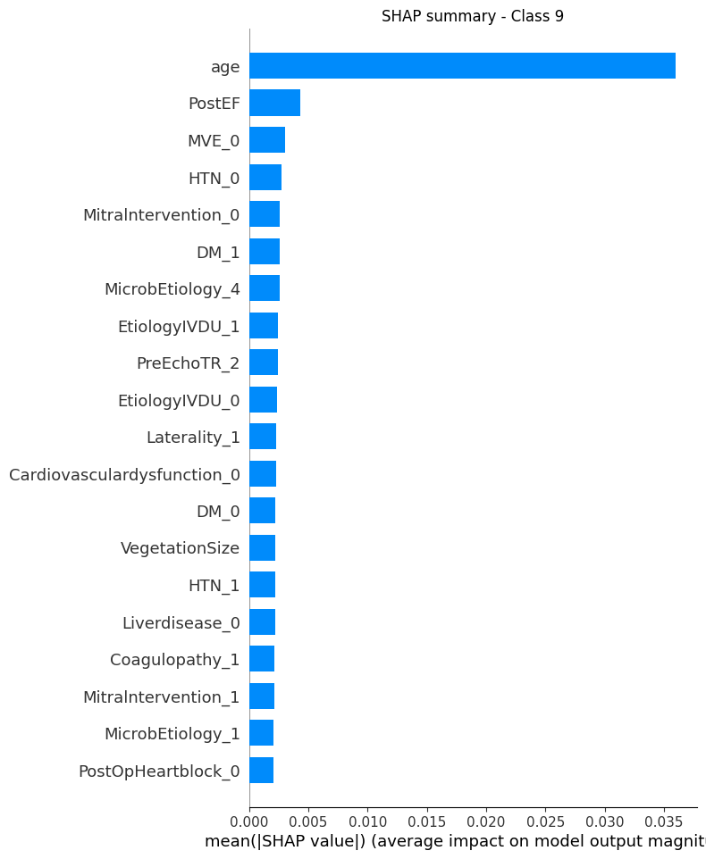

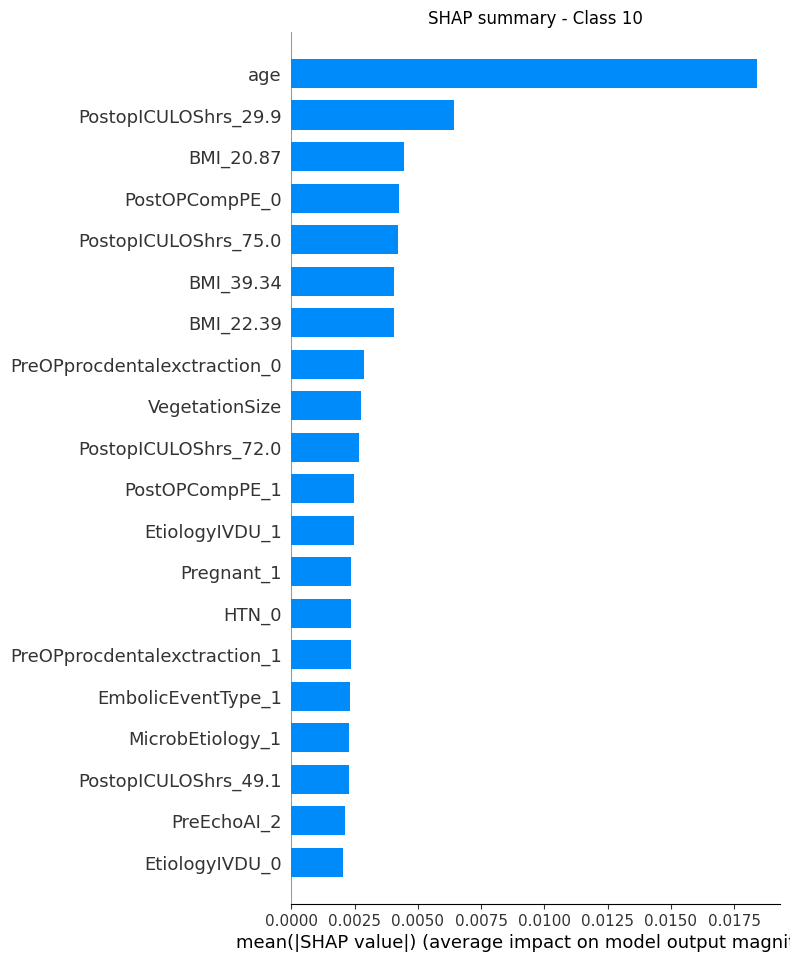

```
Top 10 SHAP Features across all classes:
[['age' 'PreEchoMR_2' 'Liverdisease_0' ... 'PostopICULOShrs_140.3'
  'BMI_24.42' 'DaysFromstroketosurgery_14.0']
 ['age' 'Tobaccouse_0' 'Cardiovasculardysfunction_1' ...
  'PostopICULOShrs_138.8' 'BMI_19.2' 'BMI_24.96']
 ['age' 'EtiologyIVDU_1' 'HTN_0' ... 'PostopICULOShrs_187.9'
  'PostopICULOShrs_159.5' 'PostopICULOShrs_51.8']
 ...
 ['age' 'Prioritystatusurgentemergent_1' 'Prioritystatusurgentemergent_0'
  ... 'BMI_31.72' 'BMI_21.6' 'BMI_39.32']
 ['age' 'EtiologyIVDU_1' 'EtiologyIVDU_0' ... 'BMI_28.84'
  'PostopICULOShrs_79.4' 'PostopICULOShrs_74.8']
 ['age' 'Prioritystatusurgentemergent_1' 'EmbolicEventType_1' ...
  'PostopICULOShrs_35.1' 'BMI_23.8' 'BMI_19.2']]
```

```python
import pandas as pd
import numpy as np
from sklearn.model_selection import train_test_split
from sklearn.preprocessing import OneHotEncoder, StandardScaler
from imblearn.over_sampling import SMOTE
from sklearn.linear_model import LogisticRegression
from sklearn.ensemble import RandomForestClassifier, GradientBoostingClassifier
from sklearn.metrics import roc_auc_score
import matplotlib.pyplot as plt
import shap

# Assuming 'new_df' and 'clean_df' are already defined

# Define categorical variables explicitly, excluding 'age' and 'VegetationSize'
categorical_vars = new_df.columns.drop(['age', 'VegetationSize','PreEF','PostEF']).tolist()

# Columns to exclude
columns_to_exclude = ['VitalstatusatlastFollowupalive1', 'combined', 'FollowupYears', 'Followupperioddays', 'TotalLOS']

# Separate and exclude specific columns from categorical variables
X_categorical = new_df[categorical_vars].drop(columns=columns_to_exclude, errors='ignore')

# One-hot encode categorical variables
encoder = OneHotEncoder(sparse=False, handle_unknown='ignore')
X_categorical_encoded = pd.DataFrame(encoder.fit_transform(X_categorical),
                                     columns=encoder.get_feature_names_out(X_categorical.columns))

# Select and scale continuous variables 'age' and 'VegetationSize'
continuous_vars = ['age', 'VegetationSize','PreEF','PostEF']
scaler = StandardScaler()
X_continuous_scaled = pd.DataFrame(scaler.fit_transform(new_df[continuous_vars]),
                                   columns=continuous_vars)

# Combine encoded categorical variables with scaled continuous variables
X_combined = pd.concat([X_continuous_scaled.reset_index(drop=True), X_categorical_encoded.reset_index(drop=True)], axis=1)

# Define the target variable
y = clean_df['t5_group']

# Splitting the data
X_train, X_test, y_train, y_test = train_test_split(X_combined, y, test_size=0.2, random_state=42)

# Use SMOTE to balance the dataset
smote = SMOTE()
X_train_smote, y_train_smote = smote.fit_resample(X_train, y_train)

# Define models
models = {
    "Logistic Regression": LogisticRegression(max_iter=1000, random_state=42),
    "Random Forest": RandomForestClassifier(random_state=42),
    "Gradient Boosting": GradientBoostingClassifier(random_state=42)
}

# Model training and ROC AUC evaluation
for name, model in models.items():
    model.fit(X_train_smote, y_train_smote)
    y_scores = model.predict_proba(X_test)

    # Compute ROC AUC score for multiclass
    roc_auc = roc_auc_score(y_test, y_scores, multi_class='ovr')
    print(f'{name} ROC AUC: {roc_auc:.2f}')

# Assuming Random Forest is the best-performing model for SHAP analysis
explainer = shap.Explainer(models['Random Forest'])
shap_values = explainer.shap_values(X_test)

# Generate SHAP summary plots for each class
for i in range(len(shap_values)):
    shap.summary_plot(shap_values[i], X_test, feature_names=X_combined.columns, plot_type="bar", show=False)
    plt.title(f'SHAP summary - Class {i}')
    plt.show()

# Extracting common top 10 SHAP scores across all classes
shap_values_combined = np.abs(shap_values).mean(0)
top_indices = np.argsort(-shap_values_combined)[:10]
top_features = np.array(X_combined.columns)[top_indices]

print("Top 10 SHAP Features across all classes:")
print(top_features)
```

```python
import numpy as np

# Assuming shap_values is an array with the shape [n_classes, n_samples, n_features]
# Calculate the mean absolute SHAP value for each feature across all classes
mean_abs_shap_values = np.abs(shap_values).mean(axis=0).mean(axis=0)

# Get the indices of the top 10 features
top_feature_indices = np.argsort(-mean_abs_shap_values)[:20]

# Extract the feature names
top_features = np.array(X_combined.columns)[top_feature_indices]

print("Top 20 SHAP Features across all classes:")
print(top_features)
```

```
Top 20 SHAP Features across all classes:
['age' 'EtiologyIVDU_1' 'EtiologyIVDU_0' 'HTN_0' 'EmbolicEventType_1'
 'HTN_1' 'PostOpHeartblock_0' 'Liverdisease_0'
 'PreOPprocdentalexctraction_0' 'MicrobEtiology_1' 'Tobaccouse_0'
 'PreOPprocdentalexctraction_1' 'Liverdisease_1' 'PreEchoMR_2'
 'Tobaccouse_1' 'DM_0' 'VegetationSize' 'PreEF' 'PostEF' 'DM_1']
```

```python
# Given the list of top features with binary encoded suffixes, we'll create a new list of unique feature names without the suffixes.



# Remove the binary encoded suffixes and get the unique feature names
top_features_unique = list(set(feature.split('_')[0] for feature in top_features))

# Print the new list of unique top features
top_features_unique
```

```
['HTN',
 'VegetationSize',
 'PreEF',
 'PostOpHeartblock',
 'Tobaccouse',
 'EtiologyIVDU',
 'Liverdisease',
 'DM',
 'EmbolicEventType',
 'MicrobEtiology',
 'age',
 'PreEchoMR',
 'PostEF',
 'PreOPprocdentalexctraction']
```

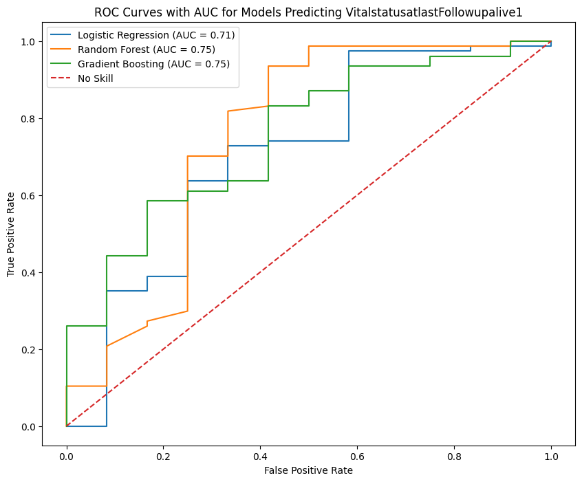

```python
from sklearn.metrics import roc_curve, auc
import matplotlib.pyplot as plt

# Assuming you have identified top features from the first model, list them here
#top_features = ['Feature1', 'Feature2', 'Feature3', ...]  # Replace with actual feature names

# Prepare the dataset with top features
X_top_features = new_df[top_features_unique]

# Define the new target variable
y_new_target = clean_df['VitalstatusatlastFollowupalive1']

# Splitting the data
X_train_new, X_test_new, y_train_new, y_test_new = train_test_split(X_top_features, y_new_target, test_size=0.2, random_state=42)

# Use SMOTE again for balancing
smote = SMOTE()
X_train_smote_new, y_train_smote_new = smote.fit_resample(X_train_new, y_train_new)

# Define models for the new target
models_new_target = {
    "Logistic Regression": LogisticRegression(max_iter=1000, random_state=42),
    "Random Forest": RandomForestClassifier(random_state=42),
    "Gradient Boosting": GradientBoostingClassifier(random_state=42)
}

# Plot ROC Curves for the new target
plt.figure(figsize=(10, 8))

for name, model in models_new_target.items():
    model.fit(X_train_smote_new, y_train_smote_new)
    y_scores_new = model.predict_proba(X_test_new)[:, 1]
    fpr_new, tpr_new, thresholds_new = roc_curve(y_test_new, y_scores_new)
    roc_auc_new = auc(fpr_new, tpr_new)
    plt.plot(fpr_new, tpr_new, label=f'{name} (AUC = {roc_auc_new:.2f})')

plt.plot([0, 1], [0, 1], linestyle='--', label='No Skill')
plt.xlabel('False Positive Rate')
plt.ylabel('True Positive Rate')
plt.title('ROC Curves with AUC for Models Predicting VitalstatusatlastFollowupalive1')
plt.legend()
plt.show()
```

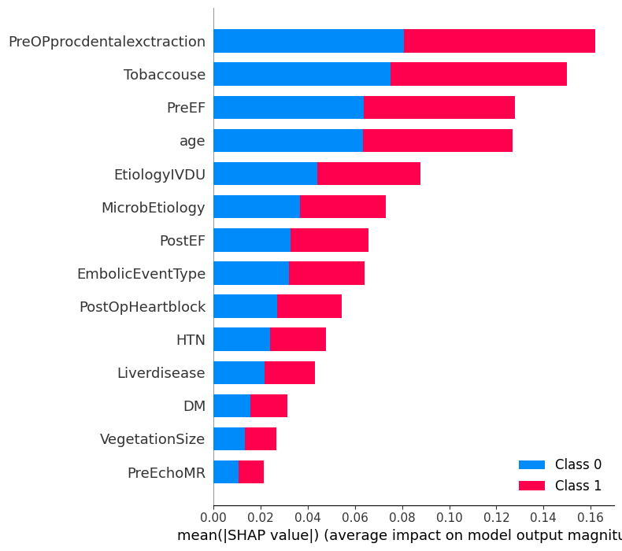

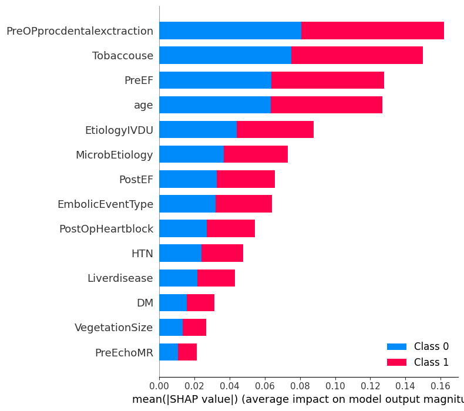

```python
import shap

# Assuming X_train_smote_new, y_train_smote_new, and X_test_new are correctly defined and preprocessed

# Train the Random Forest model on the balanced dataset
rf_model = RandomForestClassifier(random_state=42)
rf_model.fit(X_train_smote_new, y_train_smote_new)

# Calculate SHAP values
explainer = shap.Explainer(rf_model)
shap_values = explainer.shap_values(X_test_new)

# Plot summary plot of SHAP values
shap.summary_plot(shap_values, X_test_new, plot_type="bar", feature_names=X_test_new.columns)

# Plot summary plot with feature values
shap.summary_plot(shap_values, X_test_new, feature_names=X_test_new.columns)

# Plot SHAP values for a single prediction (example: first instance in test set)
shap.initjs()
# For multi-class, select the correct class's SHAP values and expected value
class_index = 1  # Change this to the class index you're interested in
shap.force_plot(explainer.expected_value[class_index], shap_values[class_index][0,:], X_test_new.iloc[0,:], feature_names=X_test_new.columns)
```